# Analisis Data Project Kelompok 18 - Praktikum MPDW Pekan 9

Farik Firsteadi Haristiyanto - G1401211015

Dewi Kunthi Siswati Suryo - G1401211017

Muhammad Luthfi Al Gifari - G1401211031

Azzahra Adelia Putri - G1401211045

2023-10-30

## Packages

```r
library(ggplot2)
library(tsibble)
library(tseries)
library(MASS)
library(forecast)
library(TSA)
library(TTR)
library(aTSA)
library(graphics)
library(rio)
```

## Input Data

### Import Data

Data yang di-import merupakan data harga saham perusahaan Microsoft sejak bulan Mei 2013 hingga April 2023.

```r
data <- import("https://raw.githubusercontent.com/Fhar1st/mpdw/main/Kelompok%2018/microsoft-stock-dataset-Monthly2.csv")
data
```

```
##          Date  Price
## 1    5/1/2013  32.93
## 2    6/1/2013  34.92
## 3    7/1/2013  34.75
## 4    8/1/2013  32.06
## 5    9/1/2013  31.75
## 6   10/1/2013  33.35
## 7   11/1/2013  35.67
## 8   12/1/2013  38.09
## 9    1/1/2014  37.35
## 10   2/1/2014  37.74
## 11   3/1/2014  37.92
## 12   4/1/2014  41.15
## 13   5/1/2014  40.24
## 14   6/1/2014  40.95
```

[output cut: 106 more lines]

```r
colnames(data) <- c("Y", "X")
str(data)
```

```
## 'data.frame':    120 obs. of  2 variables:
##  $ Y: chr  "5/1/2013" "6/1/2013" "7/1/2013" "8/1/2013" ...
##  $ X: num  32.9 34.9 34.8 32.1 31.8 ...
```

```r
dim(data)
```

```
## [1] 120   2
```

```r
data.ts <- ts(data$X)
summary(data.ts)
```

```
##    Min. 1st Qu.  Median    Mean 3rd Qu.    Max.
##   31.75   49.65   94.39  128.86  213.75  335.35
```

## Eksplorasi Data

Sebelum masuk dalam tahap pemodelan, dilakukan eksplorasi data dengan plot deret waktu untuk melihat pola data.

### Plot Data Penuh

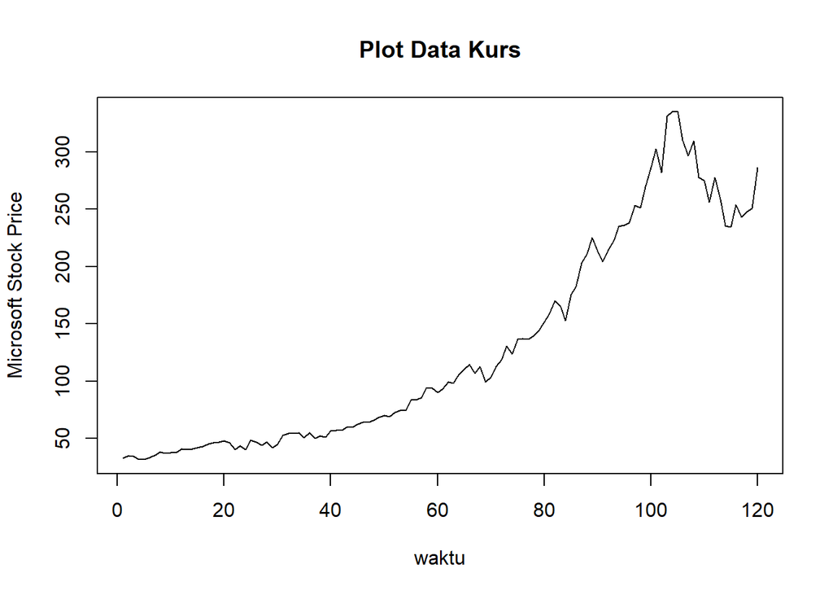

```r
#--PLOT TIME SERIES--#
plot.ts(data.ts, lty=1, xlab="waktu", ylab="Microsoft Stock Price", main="Plot Data Kurs")
```

Berdasarkan plot data deret waktu, terlihat bahwa data cenderung memiliki trend yang naik. Berdasarkan pola data, pembagian data latih dan data uji ditetapkan dengan proporsi 67%:33%.

### Plot Data Latih

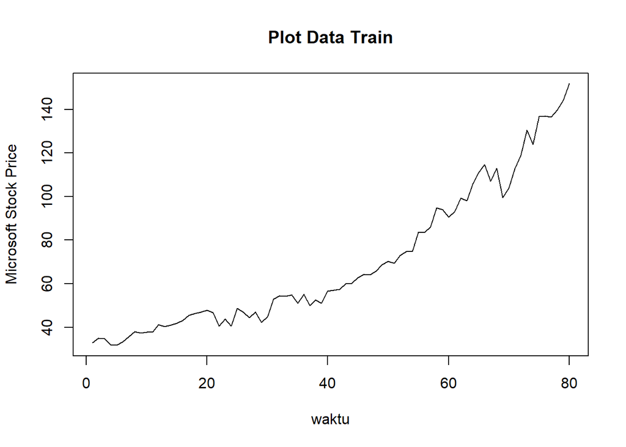

```r
data.train <- data.ts[1:80]
train.ts<-ts(data.train)
plot.ts(train.ts, lty=1, xlab="waktu", ylab="Microsoft Stock Price", main="Plot Data Train")
```

Berdasarkan plot data deret waktu pada data latih, terlihat bahwa data cenderung memiliki trend yang naik dan cenderung tidak bergerak pada nilai tengah tertentu. Hal ini mengindikasikan bahwa data tidak stasioner dalam rataan.

### Plot Data Uji

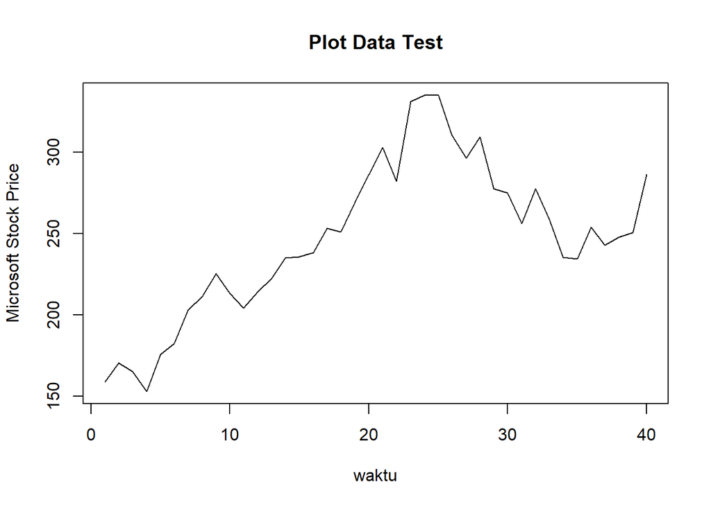

```r
data.test <- data.ts[81:120]
test.ts<-ts(data.test)
plot.ts(test.ts, lty=1, xlab="waktu", ylab="Microsoft Stock Price", main="Plot Data Test")
```